# New Market Tax Credits in New Orleans

```r
library( dplyr )
library( geojsonio )
library( sp )
library( pander )
```

### Matched Census Tracts

Treated cases received at least one New Market Tax Credit grant between 2000 and 2010.

Cases were matched to identify “twin” treated and untreated tracts in 2000 using the following variables:

- Household Income
- Percentage White
- Percent Adults > 25 with College Degree

We have created a data frame assigning each Census tract to a treated or untreated (“control”) group, and designating whether we were able to identify a twin tract or not (match = TRUE or FALSE).

The matching procedure generates a balanced study dataset where 32 out of 54 tracts that received NMTC grants were paired with “untreated” doppelganger tracts (identical in 2000), making the post-treatment period comparisons in 2010 a more robust representation of true treatment effects.

| control-matched | control-unmatched | treated-matched | treated-unmatched |
| --- | --- | --- | --- |
| 32 | 306 | 32 | 22 |

# Visualization of Matching

### Load New Orleans Cartogram

We utilize Dorling Cartogram representations of metro maps to minimize geographic distortion.

Each tract is scaled by the total population, which minimizes the visual bias predominant when the size of geographic units is inversely proportional to population density (suburban tracts are normally larger geographically because they are less densely populated, over-emphasizing their import and hiding many details in dense urban regions of the city).

```r
github.url <-
  "https://github.com/DS4PS/usa-dorling-shapefiles/raw/master/maps/metros-dorling/new-orleans-metairie-kenner-la-dorling-v2.geojson"
no <- geojson_read( x=github.url,  what="sp" )
```

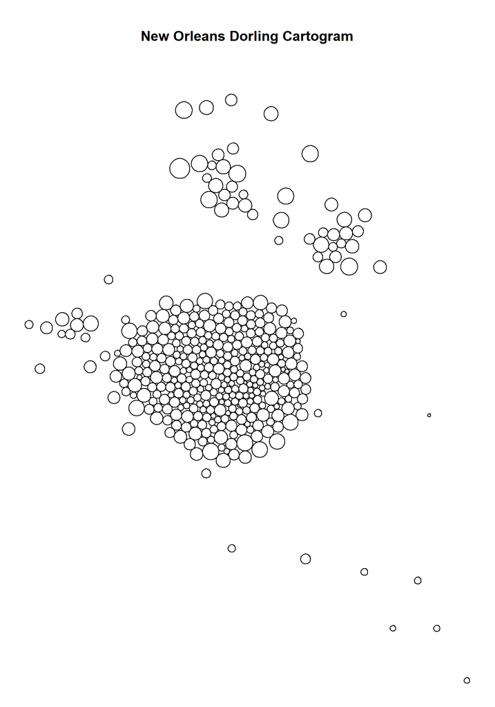

```r
par( mar=c(0,0,5,0) )
plot( no, main="New Orleans Dorling Cartogram" )
```

### Assign group colors based on matches

Data frame containing group assignment:

|  | FIPS | group | matched |
| --- | --- | --- | --- |
| 1 | 22051020502 | treated | TRUE |
| 2 | 22051020508 | treated | TRUE |
| 3 | 22051020600 | treated | TRUE |
| 4 | 22051024202 | treated | TRUE |
| 5 | 22051025900 | treated | TRUE |
| 6 | 22051026000 | treated | TRUE |

Generation of color vectors associated with group membership:

```r
m2 <- ifelse( df$matched, "matched", "unmatched" )
g <- paste( df$group, m2, sep="-" )

color.vector <- rep( "gray80", nrow(df) )
color.vector[ g == "control-matched" ] <- "blue"
color.vector[ g == "treated-matched" ] <- "darkred"
color.vector[ g == "treated-unmatched" ] <- adjustcolor( "darkred", alpha.f = 0.3 )

border.color <- rep( "gray40", nrow(df) )
border.color [ g == "treated-unmatched" ] <- "darkred"


# add back to the data frame
df$m2 <- m2
df$g <- g
df$color.vector <- color.vector
df$border.color <- border.color
```

Merge group structure into the New Orleans shapefile:

```r
NOLA <- merge( no, df, by.x="GEOID", by.y="FIPS", all.x=TRUE )
```

Visually display matched cases:

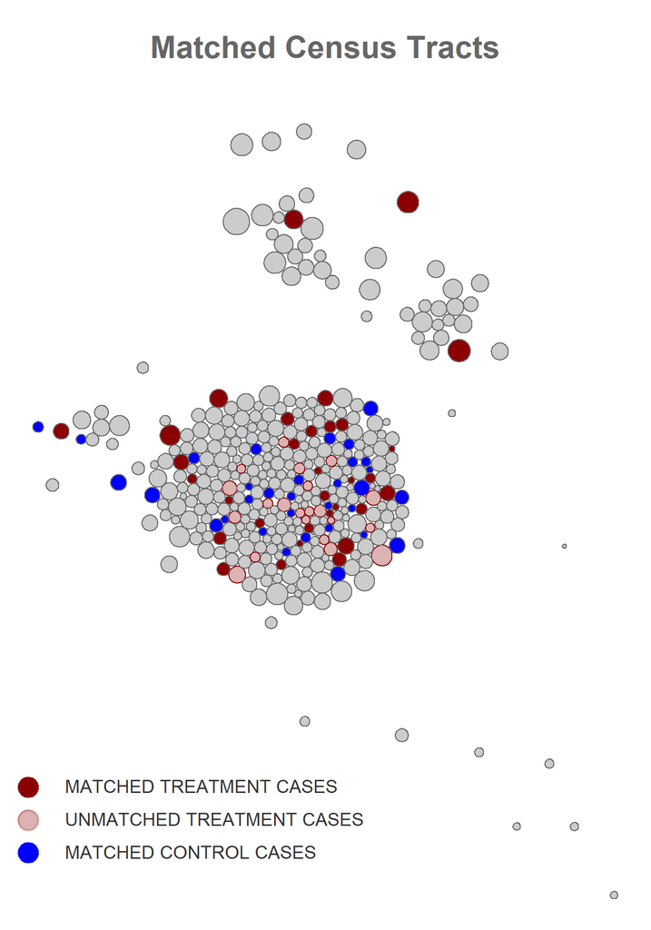

```r
par(mar=c(0,0,5,0))
plot( NOLA, col=NOLA$color.vector,
      border=NOLA$border.color,
      main="Matched Census Tracts",
      cex.main=2, col.main="gray40")

points( -90.65, 29.42, pch=19, col="darkred", cex=3 )
text( -90.65, 29.42, "MATCHED TREATMENT CASES",
      col="gray20", cex=1.2, pos=4, offset=2 )

points( -90.65, 29.36, pch=19,
        col=adjustcolor( "darkred", alpha.f = 0.3 ),
        border="darkred", cex=3, lwd=2 )
text( -90.65, 29.36, "UNMATCHED TREATMENT CASES",
      col="gray20", cex=1.2, pos=4, offset=2 )

points( -90.65, 29.30, pch=19, col="blue", cex=3 )
text( -90.65, 29.30, "MATCHED CONTROL CASES",
      col="gray20", cex=1.2, pos=4, offset=2 )
```